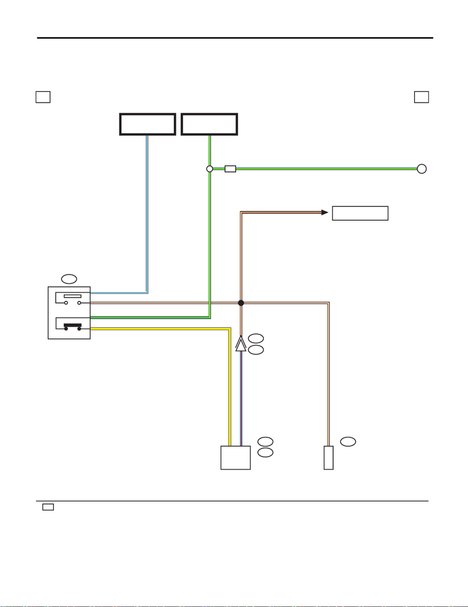

WI-359

Remote Engine Start System

WIRING SYSTEM

46.Remote Engine Start System

A: WIRING DIAGRAM

1. ENGINE TYPE FA

WI-44551

B134A:

E158B:

B65

B280A:

7

1a 1a

W/L

BR/W2

Y4

G/Y

1

3

BR/W

W/L

G/Y

L/RB8

YA43

BR/WA10

E3

B22

WP

A

L/R

BR/W

G/Y

WP

ECM

: WITH PUSH BUTTON START

REF. TO STOP LIGHT

SYSTEM [1a]

FB-32

F/B FUSE NO. 4

(IG)

FB-3

F/B FUSE NO. 8

(B)

BODY

INTEGRATED UNIT

STOP LIGHT &

BRAKE SWITCH

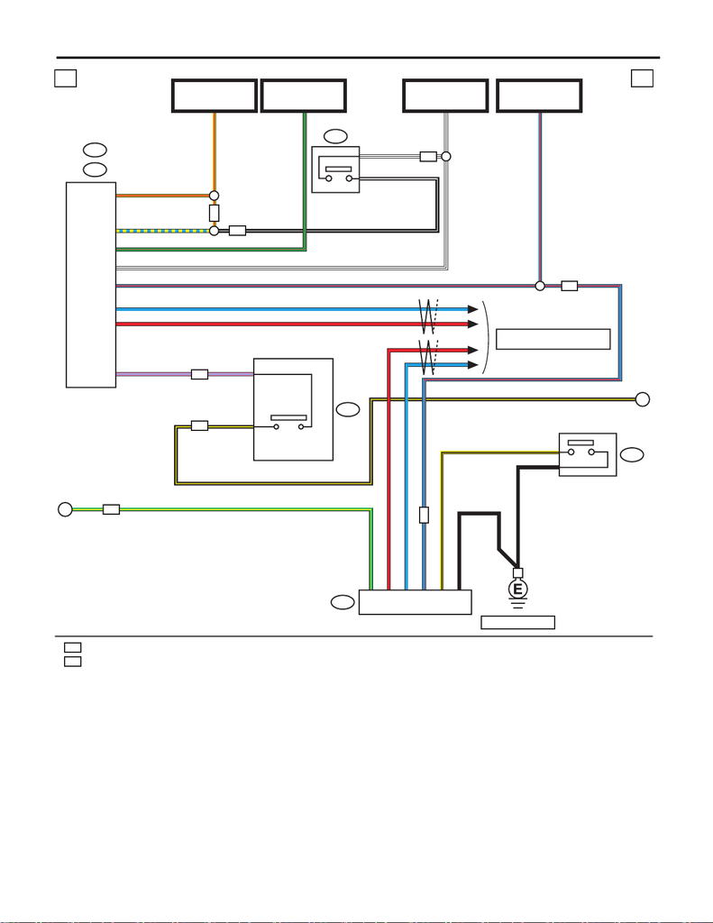

WI-360

Remote Engine Start System

WIRING SYSTEM

B280

B281

WI-44552

A32

2

1

B18

B28

B20

B180

B321

B116

B555

A:

B:

1b 1b

2

1

B7

B3

B6

5

Y/R

B/W

W/B

L

W/B

G/R

P/L

R

G/R

3

5

4

R

L

L

R

WP

1

2

R

L

1

G/Y6

L/R1

B

3

Y/B

4

2

WP

CVT

CVT

WP

WP

A

B

OP

OP

B/Y

A4

P/L

L/R

W/B

Y/R

L/R

1

2

Y/B

B

B

B

G/Y

B/Y

OP

WP

: WITH PUSH BUTTON START

: WITHOUT PUSH BUTTON START

HOOD SWITCH

: WITHOUT PUSH BUTTON START : 2

WITH PUSH BUTTON START : 3

: WITHOUT PUSH BUTTON START : 1

WITH PUSH BUTTON START : 2

REF. TO CAN COMMUNICATION

SYSTEM [a] [b]

MB-29

M/B FUSE NO. 8

(B)

MB-28

M/B FUSE NO. 14

(B)

FB-29

F/B FUSE NO. 31

(ACC)

FB-38

F/B FUSE NO. 12

(IG)

KEY WARNING

SWITCH

SELECT LEVER

REF. TO GND [b] [d]

: WITHOUT PUSH BUTTON START : 4

WITH PUSH BUTTON START : 5

: WITHOUT PUSH BUTTON START : B/W

WITH PUSH BUTTON START : Y/R

: WITHOUT PUSH BUTTON START : 3

WITH PUSH BUTTON START : 4

BODY

INTEGRATED

UNIT

P RANGE

SWITCH

REMOTE ENGINE START CM

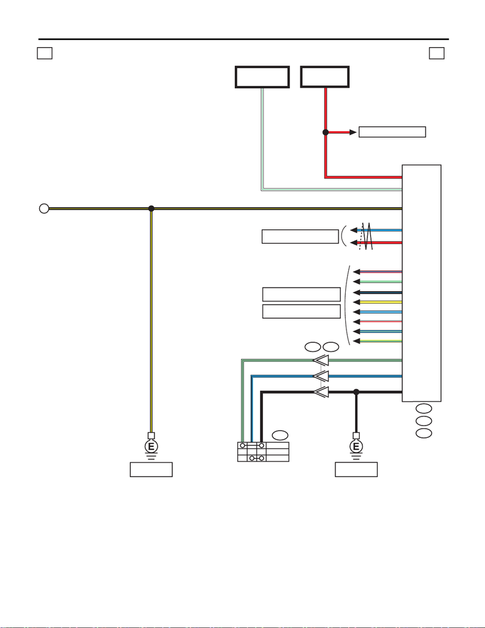

WI-361

Remote Engine Start System

WIRING SYSTEM

WI-44553

15

16

3

A: B280

C: i84

D: i171

1c 1c

B/Y

B

B

i101

D84

R A24

W/G D1

R C27

L C35

Y/L C33

A1

A9

A3

L/O C13

W/R C25

BBC1

L/B C20

LG/B

B

L/B

LG/B C9

L/W C14

Y/W C24

B/L D7

LG D3

R/L D2

A1

B/Y

R

R

W/G

B/Y

D7A:

LOCK

OFF

UNLOCK

REF. TO GND

[c] [d]

REF. TO GND

[e] [j]

REF. TO CAN COMMUNICATION

SYSTEM [b]

MB-21

HORN RELAY

FB-6

F/B FUSE NO. 3

(B)

REF. TO HORN SYSTEM [a]

BODY

INTEGRATED UNIT

REF. TO KEYLESS ENTRY

SYSTEM [a] [c] [d]

REF. TO KEYLESS ACCESS

SYSTEM [1b] [1c] [1d]

POWER WINDOW

MAIN SWITCH

(DOOR LOCK SWITCH)

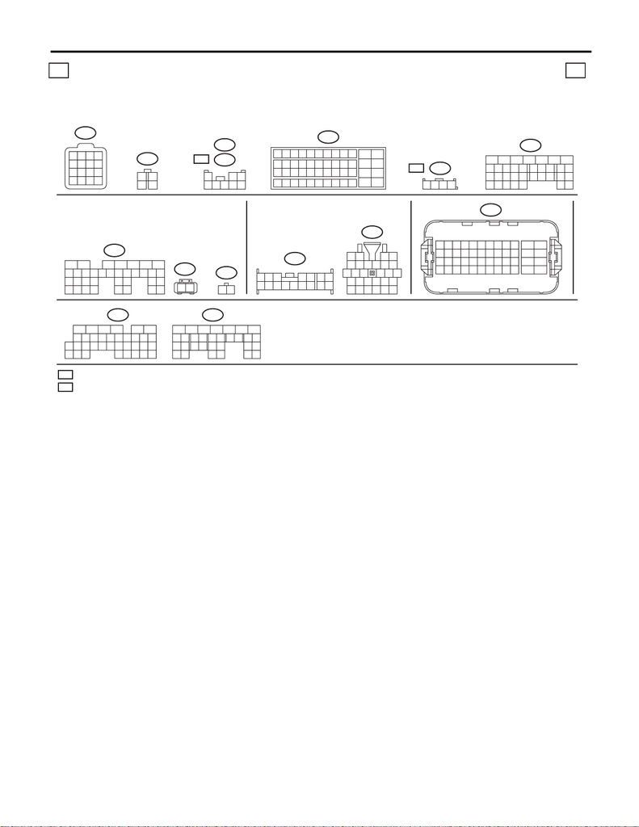

WI-362

Remote Engine Start System

WIRING SYSTEM

B180

341

2

OP

:

OP

WP

WI-44554

1d 1d

(BR)

B22

12

3

4

5678

9

10 11 12

1413 15 16

(B)

B65

12

34

B116

123

45678

B180

WP

:

10

11 12

23 24

35 36

47 48

3

5

6

7894

12

45

21

2219 2017 1815 1613 14

33

3431 3229 3027 2825 26

(BR)

B134

A:

B280

18

2719 20 21 22

23

26

24

25

28 29 3332 3430 31

98

15

1413121110

17

16

1234567

A:

B281B:

5672134

29

10 11 12 13 14 15

2524

16

30

98

17 18 19

20

28

21 22 23

3231

26 27

33 34 35

B321

(B)

21

B555

12

D7

123

89

10

4

11 12 13 14 15 16

56

7

A:

D84

19

18

20 21 22

1514131211

1

3

24

5

7

6

98

10

17

25

24

26 27 2823

16

E158

(B)

79

10

85

23

11 12

6

19 21 222017

24

35 36

47 48

18

31 33 343229 30

43 45 464441 42

3412

15 1613 14

27 2825 26

39 4037 38

B:

i84C:

19

18

21

20

2322 24 25 26

17

1

23

4

56

27

28 29 30

31 32 33 34 35

798

151413121110 16

i171D:

19

18

20 21

22

23

26

24

25

27

28 29

30 31

98

15

1413121110

17

16

1234567

: WITHOUT PUSH BUTTON START

: WITH PUSH BUTTON START

LIST OF CONNECTORS

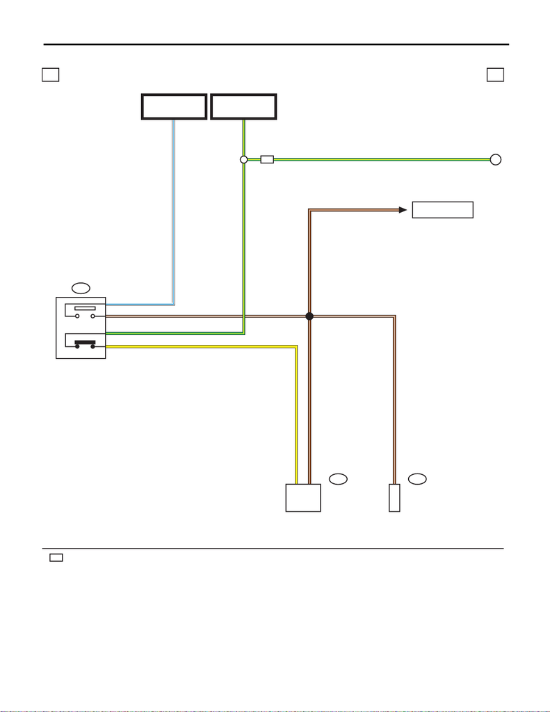

WI-363

Remote Engine Start System

WIRING SYSTEM

2. ENGINE TYPE EJ

ECM

B136C:

B65

B280A:

WI-44555

2a 2a

W/L

BR/W2

Y4

G/Y

1

3

W/L

G/Y

BR/WC3

YC15

BR/WA10

BR/W

WP

WP

G/Y

A

REF. TO STOP LIGHT

SYSTEM [2a]

: WITH PUSH BUTTON START

FB-3

F/B FUSE NO. 8

(B)

FB-32

F/B FUSE NO. 4

(IG)

BODY

INTEGRATED UNIT

STOP LIGHT &

BRAKE SWITCH

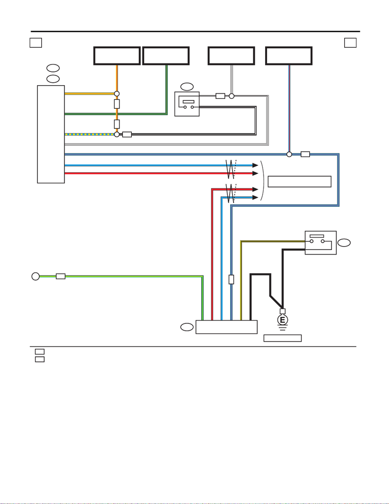

WI-364

Remote Engine Start System

WIRING SYSTEM

B280

B281

B180

B321

B555

WI-44556

A32

B28

B20

A:

B:

WP

OP

OP

WP

WP

2b 2b

G/R

Y/R

L

W/B

1

B/W

2

R

1

2

R

L

G/R

2

G/Y6

L/R1

B

4

Y/B

5

3

1

2

1 W/B

L

R

R

L

B7

A4

B6

WP

WP

A

Y/B

B

L/R

W/B

Y/R

L/R

OP

WP

4

5

3

B3

B

B

G/Y

: WITHOUT PUSH BUTTON START : 2

WITH PUSH BUTTON START : 3

: WITHOUT PUSH BUTTON START : 4

WITH PUSH BUTTON START : 5

: WITHOUT PUSH BUTTON START : 3

WITH PUSH BUTTON START : 4

: WITH PUSH BUTTON START

: WITHOUT PUSH BUTTON START

REF. TO CAN COMMUNICATION

SYSTEM [a] [b]

MB-29

M/B FUSE NO. 8

(B)

MB-28

M/B FUSE NO. 14

(B)

FB-29

F/B FUSE NO. 31

(ACC)

FB-38

F/B FUSE NO. 12

(IG)

HOOD SWITCH

REF. TO GND [b] [d]

: WITHOUT PUSH BUTTON START : 1

WITH PUSH BUTTON START : 2

: WITHOUT PUSH BUTTON START : B/W

WITH PUSH BUTTON START : Y/R

BODY

INTEGRATED

UNIT

KEY WARNING

SWITCH

REMOTE ENGINE START CM

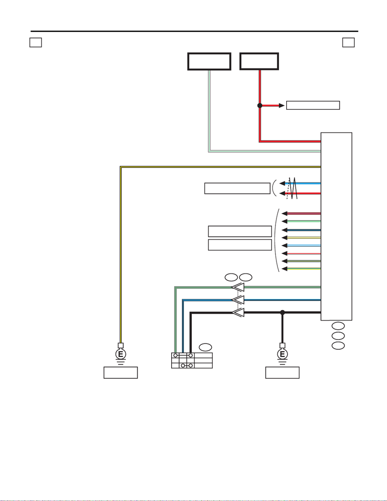

WI-365

Remote Engine Start System

WIRING SYSTEM

WI-44557

15

16

3

A: B280

C: i84

D: i171

2c 2c

B/Y

B

D84 i101

R A24

W/G D1

R C27

L C35

C33Y/L

L/O C13

W/R C25

C1

L/B

B

C20

LG/B C9

L/W C14

Y/W C24

B/L D7

LG D3

R/L D2

A1

B/Y

R

R

W/G

A1

A9

A3

B

L/B

LG/B

D7A:

LOCK

OFF

UNLOCK

REF. TO GND

[c]

REF. TO GND

[e] [j]

REF. TO CAN COMMUNICATION

SYSTEM [b]

MB-21

HORN RELAY

FB-6

F/B FUSE NO. 3

(B)

REF. TO HORN SYSTEM [a]

BODY

INTEGRATED UNIT

REF. TO KEYLESS ENTRY

SYSTEM [a] [c] [d]

REF. TO KEYLESS ACCESS

SYSTEM [2b] [2c] [2d]

POWER WINDOW

MAIN SWITCH

(DOOR LOCK SWITCH)

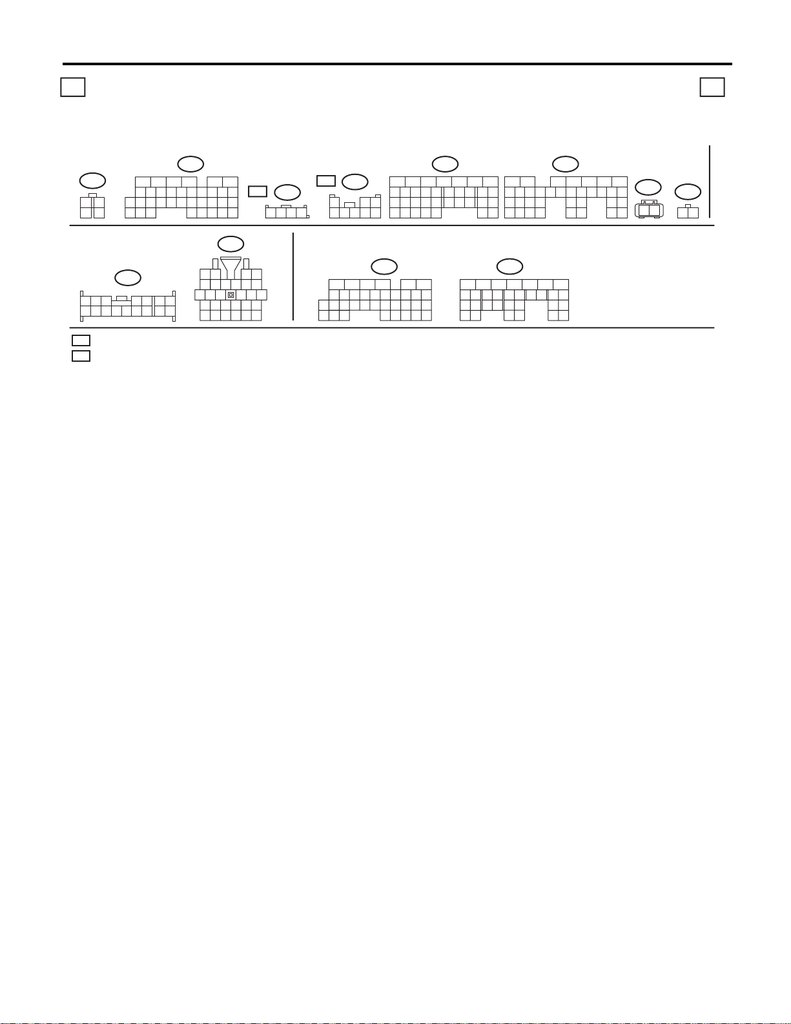

WI-366

Remote Engine Start System

WIRING SYSTEM

OP

WP

123

45678

B180

WP

:

WI-44558

2d 2d

(B)

B65

12

34

B280

18

2719 20 21 22

23

26

24

25

98

15

1413121110

17

16

1234567

A:

B281B:

5672134

29

10 11 12 13 14 15

2524

16

30

98

17 18 19

20

28

21 22 23

3231

26 27

33 34 35

B321

(B)

21

B555

12

D7

123

89

10

4

11 12 13 14 15 16

56

7

A:

D84

19

18

20 21 22

1514131211

1

3

24

5

7

6

98

10

17

25

24

26 27 2823

16

i84C:

19

18

21

20

2322 24 25 26

17

1

23

4

56

27

28 29 30

31 32 33 34 35

798

151413121110 16

i171D:

19

18

20 21

22

23

26

24

25

27

28 29

30 31

98

15

1413121110

17

16

1234567

OP

:

B180

341

2

B136C:

19

18

21

20

2322 24 25 26

17

1

23

4

56

27

28 29 30

31 32 33 34 35

798

151413121110 16

: WITHOUT PUSH BUTTON START

: WITH PUSH BUTTON START

LIST OF CONNECTORS